# CGRverk6

CGR

2023-03-22

```r
library(readr)
library(dplyr)
```

```r
library(ggplot2)
library(kableExtra)
library(tidyverse)
library(GGally)
library(skimr)
library(data.table)
library(DataExplorer)
library(car)
```

# Verkefni 6

## Import Dataset

#Veljið ykkur eina nýja flokkabreytu til að skoða til viðbótar við breyturnar tvær sem þið skoðuðuð í R verkefni 5.

[figure not shown]

```r
data0 <- read.csv("Handahofskenndar_spurningar_um_lifid.csv", header=T, fill=T, dec=",", sep=";", fileEncoding = 'UTF-8-BOM')
data1 <- na.omit(data0)

data_full <- data1 %>%
  dplyr::select("Hvað.heldur.þú.að.500.gr.af.smjöri.kosti.í.Bónus.", "Hvort.ertu.meira.fyrir.", "Hvaða.stýrikerfi.er.á.símanum.þínum." )

data_c <- data_full[data_full$Hvað.heldur.þú.að.500.gr.af.smjöri.kosti.í.Bónus. <= 800 & data_full$Hvað.heldur.þú.að.500.gr.af.smjöri.kosti.í.Bónus. >= 140, ]

data_c %>%
  plot_missing()
```

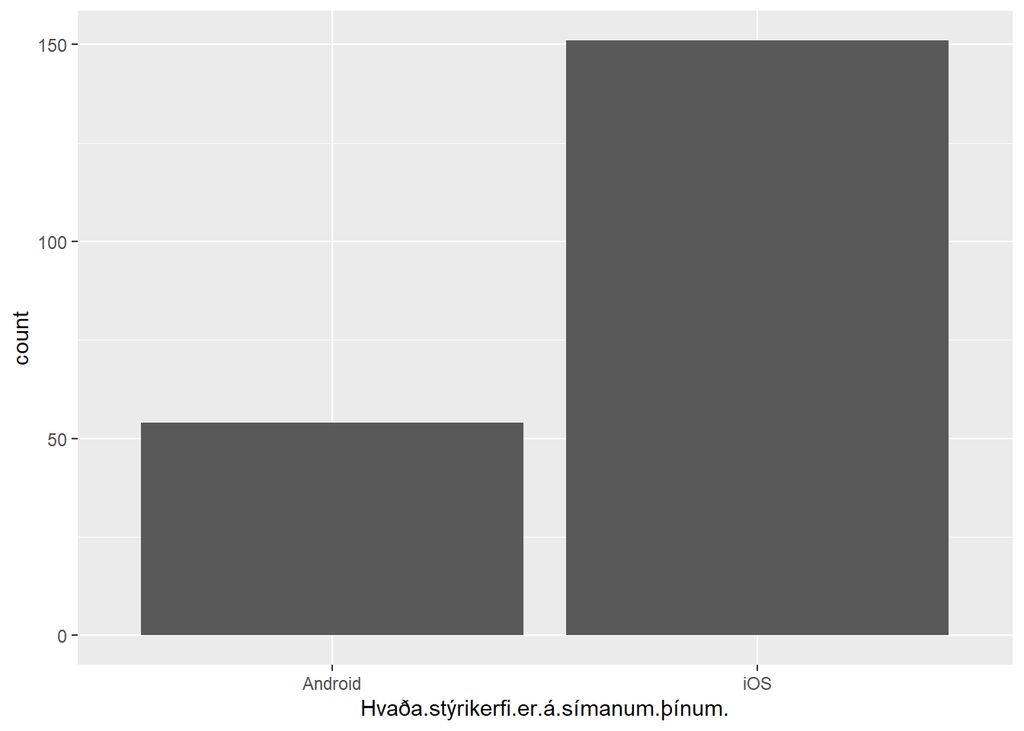

```r
ggplot(data_c, aes(x = Hvaða.stýrikerfi.er.á.símanum.þínum.)) +
  geom_bar()
```

```r
#merge cat&dogs with cats column
data_f <- data_c %>%
  mutate(type = factor(case_when (Hvort.ertu.meira.fyrir. == "Ketti" ~ "Cat &/ Dog",
                                Hvort.ertu.meira.fyrir. == "Hunda" ~ "Dog",
                                Hvort.ertu.meira.fyrir. == "Hunda,Ketti" ~ "Cat &/ Dog")))

#levels
data_f$dog_cat <- data_f$type
levels(data_f$dog_cat)
```

```
## [1] "Cat &/ Dog" "Dog"
```

```r
#factor & levels new categorical variable
data_g <- data_f %>%
  mutate(ios_android = as.factor(Hvaða.stýrikerfi.er.á.símanum.þínum.))
levels(data_g$ios_android)
```

```
## [1] "Android" "iOS"
```

```r
#make a dataframe
verk6 <- data.frame(num= data_g$Hvað.heldur.þú.að.500.gr.af.smjöri.kosti.í.Bónus., dog_cat=data_g$dog_cat, ios_android=data_g$ios_android)
```

# Skoðið myndrænt sambandið milli gömlu flokkabreytunnar og nýju flokkabreytunnar (t.d. með stöplariti)

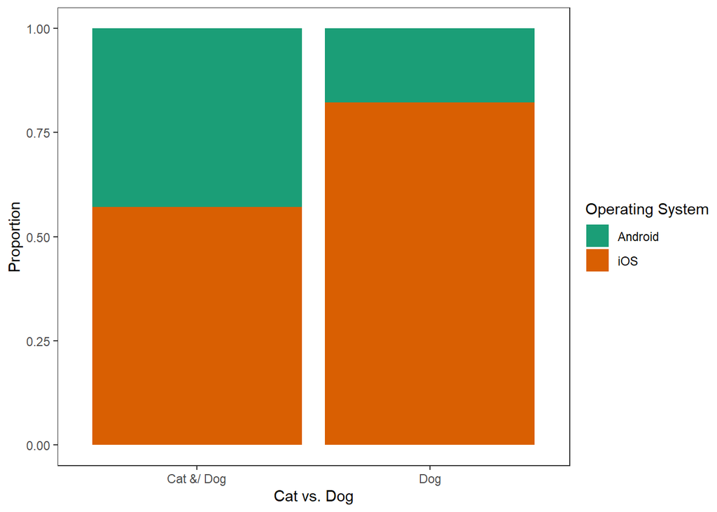

```r
verk6 %>%
  count(dog_cat, ios_android) %>%
  ggplot() +
  aes(x = dog_cat, y = n, fill = factor(ios_android)) +
  geom_col(position = "fill") +
  scale_fill_brewer(palette = "Dark2", direction = 1) +
  labs(x  = "Cat vs. Dog", y = "Proportion", fill = "Operating System") +
  theme_test()
```

# Smíðið tilgátu sem kannar hvort það séu tengls milli flokkabreytanna tveggja.

Categorical Variable 1: The amount of people who prefer dogs vs. cats(&people who are indifferent)

Categorical Variable 2: The amount of people who use iOS and those who use Android

Chi-squared: The null hypothesis for the chi-squared test of independence is that there is no relationship between the two categorical variables. In other words, the two variables are independent of each other.

The alternative hypothesis is that there is a relationship between the two variables.

*When we say that there is a relationship between two categorical variables, we mean that the values of one variable are somehow related to or associated with the values of the other variable. In other words, knowing the category of one variable gives us some information about the likely category of the other variable.*

The alternative hypothesis would be that the proportions are not equal.

# Notið tilgátupróf fyrir flokkabreytur til að kanna tilgátuna.

```r
chisq.test(verk6$dog_cat, verk6$ios_android)
```

```
##
##  Pearson's Chi-squared test with Yates' continuity correction
##
## data:  verk6$dog_cat and verk6$ios_android
## X-squared = 13.679, df = 1, p-value = 0.0002169
```

We want to know if the preference for dogs vs. cats is the same as the preference for iOS vs. Android, or if there is a significant difference between the two.

```r
prop.test(table(verk6$dog_cat, verk6$ios_android))
```

```
##
##  2-sample test for equality of proportions with continuity correction
##
## data:  table(verk6$dog_cat, verk6$ios_android)
## X-squared = 13.679, df = 1, p-value = 0.0002169
## alternative hypothesis: two.sided
## 95 percent confidence interval:
##  0.1072863 0.3943010
## sample estimates:
##    prop 1    prop 2
## 0.4285714 0.1777778
```

# Túlkið niðurstöðu prófsins.

According to the Pearson´s chi-squared test, there is a statistically significant association between the two categorical variables since the p-value was very low 0.0002169.

# Notið tilgátupróf fyrir talnabreytur til að kanna hvort það sé munur á meðaltölum gömlu talnabreytunnar á milli hópanna tveggja í gömlu flokkabreytunni. Þ.e.a.s. nákvæmlega sömu tvær breytur og þið gerðuð umraðanaprófið í kafla 5 fyrir nema nú er lýsistærðin meðaltal hjá ykkur öllum.

There are several assumptions that should be checked before performing a t test: 1. Normality 2. Homogeneity of variance 3. Independence

### Normality

[figure not shown]

```r
par(mfrow=c(1,2))
qqplot(x = verk6$dog_cat, y=verk6$num)
qqplot(verk6$ios_android, y=verk6$num)
```

Normality tests are not appropriate for a categorical variable, because normality is a concept that applies only to continuous data.

```r
shapiro.test(verk6$num)
```

```
##
##  Shapiro-Wilk normality test
##
## data:  verk6$num
## W = 0.97887, p-value = 0.003525
```

```r
ks.test(verk6$num, "pnorm", mean = mean(verk6$num), sd = sd(verk6$num))
```

```
##
##  Asymptotic one-sample Kolmogorov-Smirnov test
##
## data:  verk6$num
## D = 0.087958, p-value = 0.08383
## alternative hypothesis: two-sided
```

Shapiro-Wilk: Ho: the numerical variable is normally distributed.

In this case, the p-value is 0.003525 which is less than 0.05, so we can reject the null hypothesis and conclude that the data is not normally distributed.

Kolmogorov-Smirnov: Ho: numerical data is from a normal distribution

### Homogeneity of variance

Null hypothesis of the levene’s test: the variance of the numerical variable is equal between the two groups (dog vs. cat) of the categorical variable dog_cat.

```r
leveneTest(num ~ dog_cat, data=verk6)
```

```
## Levene's Test for Homogeneity of Variance (center = median)
##        Df F value Pr(>F)
## group   1  0.5559 0.4568
##       203
```

Since the p-value is greater than the significance level of 0.05, we fail to reject the null hypothesis. Therefore, we can conclude that there is not enough evidence to suggest that the variance of the num variable is different between the two groups defined by dog_cat.

Null hypothesis of the levene’s test: the variance of the numerical variable is equal between the two groups (ios vs. android) of the categorical variable ios_android.

```r
leveneTest(num ~ ios_android, data=verk6)
```

```
## Levene's Test for Homogeneity of Variance (center = median)
##        Df F value Pr(>F)
## group   1   0.584 0.4456
##       203
```

In both cases, the p-value is greater than 0.05, which suggests that there is no significant evidence to reject the null hypothesis of equal variances between the two groups. Therefore, we can assume that the variances are equal and it is appropriate to perform a two-sample t-test to compare the means of the two groups.

### Independence

```r
chisq.test(table(verk6$dog_cat, verk6$ios_android ))
```

```
##
##  Pearson's Chi-squared test with Yates' continuity correction
##
## data:  table(verk6$dog_cat, verk6$ios_android)
## X-squared = 13.679, df = 1, p-value = 0.0002169
```

### T-test

Regardless of the assumptions tests above, a t-test is required for this assignment. In the t-test, we are testing whether there is a significant difference in the mean price of 500g of butter in Iceland between those who prefer dogs versus those who prefer cats.

The null hypothesis is that there is no difference between the two means, and the alternative hypothesis is that there is a difference between the two means.

The “two.sided” alternative indicates that we are testing for any difference in the means, regardless of the direction (i.e., whether dog lovers estimate the price higher or lower than cat lovers).

```r
t.test(num ~ dog_cat, data=verk6, alternative='two.sided')
```

```
##
##  Welch Two Sample t-test
##
## data:  num by dog_cat
## t = 0.37914, df = 151.97, p-value = 0.7051
## alternative hypothesis: true difference in means between group Cat &/ Dog and group Dog is not equal to 0
## 95 percent confidence interval:
##  -33.42550  49.30063
## sample estimates:
## mean in group Cat &/ Dog        mean in group Dog
##                 470.0857                 462.1481
```

### Permutation Test

```r
#create a vector of mean values where each value corresponds to one of the unique values in the verk5$cat column (either Dog or Cat&/Dog)
tapply(verk6$num, verk6$dog_cat, mean)
```

```
## Cat &/ Dog        Dog
##   470.0857   462.1481
```

```r
#create a vector of differences by calculating the diff between the means of both groups
diff(tapply(verk6$num, verk6$dog_cat, mean))
```

```
##       Dog
## -7.937566
```

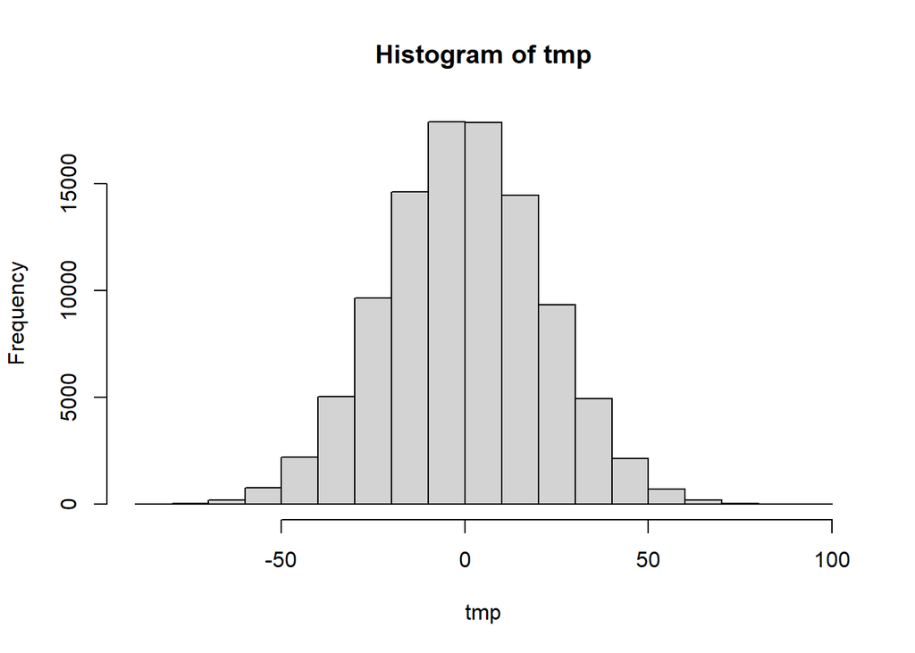

```r
#generate 100000 random permutations of the categorical variable verk5$cat
tmp <- replicate(100000, diff(tapply(verk6$num, sample(verk6$dog_cat), mean)))

#histogram that shows the distribution of differences between mean values under random permutations of the categorical variable
hist(tmp)
```

```r
#critical values at a 0.05 significance level
quantile(tmp, c(0.025, 0.975))
```

```
##      2.5%     97.5%
## -42.38679  41.93492
```

```r
#If the observed difference between mean values is outside this range, we can reject the null hypothesis that there is no difference between groups.
```

# Túlkið niðurstöður prófsins.

The t-test and permutation test are both used to compare the means of two groups, dog vs. cat(+indifferent people), but they have different underlying assumptions and hypotheses.

The permutation test, on the other hand, does not make any assumptions about the distribution of the data or the variances of the groups. It randomly permutes the two groups and calculates the difference in means between the permuted groups. This process is repeated many times to generate a null distribution of mean differences. The null hypothesis is that the group labels (ie. dog vs. cat(+indifferent people)) have no effect on the mean, and the alternative hypothesis is that they do have an effect.

# Bonus: Hugleiðið muninn á niðurstöðunni sem þið fenguð með umraðanaprófi og niðurstöðunni sem þið fáið þegar þið notið hefðbundin tilgátupróf til að draga ályktanir um talnabreytur. Var mikill munur? Hver haldið þið að ástæðan sé? Var sama lýsistærð? Eru allar forsendur tilgátuprófsins uppfylltar?

Overall, the t-test and permutation test give slightly different results because they have different assumptions and hypotheses. The permutation test is more robust and does not make any distributional assumptions.